# Final Project

## 4.2 Normal Distribution

Next, we will check to see that our residuals are normally distributed.

```r
pca_resid <- principal(final_scaled_data_pca, nfactors = 4, rotate = "none")
pca_resid
```

```
## Principal Components Analysis
## Call: principal(r = final_scaled_data_pca, nfactors = 4, rotate = "none")
## Standardized loadings (pattern matrix) based upon correlation matrix
##                                      PC1   PC2   PC3   PC4   h2    u2 com
## Average_Test_Scores                 0.93  0.15  0.20  0.22 0.98 0.024 1.3
## Average_Scores_EcoDisadvantaged     0.71 -0.13  0.47  0.39 0.90 0.101 2.5
## Average_Scores_NotEcoDisadvantaged  0.75  0.31  0.16  0.43 0.87 0.132 2.1
## Percent_English_Language_Learner   -0.42  0.69  0.36 -0.03 0.77 0.226 2.2
## Percent_Special_Education           0.34 -0.44 -0.30  0.19 0.44 0.564 3.1
## Percent_Asian                       0.10  0.63 -0.49  0.05 0.65 0.352 2.0
## Percent_Hispanic                   -0.52  0.61  0.44 -0.04 0.84 0.159 2.8
## Percent_White                       0.76 -0.51 -0.01 -0.11 0.85 0.149 1.8
## Percent_EcoDisadvantaged           -0.87 -0.16  0.12  0.27 0.87 0.126 1.3
## Total_Enrollment                    0.02  0.58 -0.39  0.35 0.61 0.387 2.5
## Percent_Bachelors                   0.48  0.59 -0.29 -0.01 0.66 0.335 2.4
## Percent_Unemployed                 -0.68 -0.27 -0.25  0.42 0.77 0.229 2.3
## Population_Poverty                 -0.69 -0.26  0.04  0.44 0.75 0.250 2.0
##
##                        PC1  PC2  PC3  PC4
## SS loadings           5.02 2.68 1.26 1.01
## Proportion Var        0.39 0.21 0.10 0.08
## Cumulative Var        0.39 0.59 0.69 0.77
## Proportion Explained  0.50 0.27 0.13 0.10
## Cumulative Proportion 0.50 0.77 0.90 1.00
##
## Mean item complexity =  2.2
## Test of the hypothesis that 4 components are sufficient.
##
## The root mean square of the residuals (RMSR) is  0.06
##  with the empirical chi square  586.41  with prob <  3.8e-103
##
## Fit based upon off diagonal values = 0.97
```

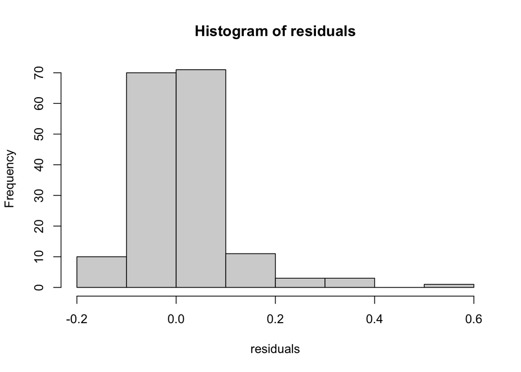

```r
#residuals
#we need correlation matrix
corMatrix<-cor(final_scaled_data_pca)

#next, create an object for residuals
residuals<-factor.residuals(corMatrix, pca_resid$loadings)

#call histogram to check for residuals
hist(residuals) #looks like a pretty normal distribution with a slight right skew
```

## 4.3 Final PCA

Since our factors are most likely related, we will use the oblique technique (promax).

```r
pca_final <- principal(final_scaled_data_pca, nfactors = 4, rotate = "promax") #oblique
pca_final #results
```

```
## Principal Components Analysis
## Call: principal(r = final_scaled_data_pca, nfactors = 4, rotate = "promax")
## Standardized loadings (pattern matrix) based upon correlation matrix
##                                      RC1   RC2   RC4   RC3   h2    u2 com
## Average_Test_Scores                -0.28 -0.04  0.77  0.08 0.98 0.024 1.3
## Average_Scores_EcoDisadvantaged     0.08  0.04  1.00 -0.25 0.90 0.101 1.1
## Average_Scores_NotEcoDisadvantaged  0.00  0.08  0.88  0.27 0.87 0.132 1.2
## Percent_English_Language_Learner   -0.04  0.90  0.09  0.06 0.77 0.226 1.0
## Percent_Special_Education           0.19 -0.68  0.10  0.09 0.44 0.564 1.2
## Percent_Asian                      -0.13  0.00 -0.18  0.78 0.65 0.352 1.2
## Percent_Hispanic                    0.00  0.95  0.07 -0.07 0.84 0.159 1.0
## Percent_White                      -0.36 -0.59  0.18 -0.27 0.85 0.149 2.4
## Percent_EcoDisadvantaged            0.77  0.23 -0.06 -0.15 0.87 0.126 1.3
## Total_Enrollment                    0.25  0.03  0.13  0.79 0.61 0.387 1.3
## Percent_Bachelors                  -0.39  0.01  0.06  0.61 0.66 0.335 1.7
## Percent_Unemployed                  0.90 -0.22 -0.09  0.16 0.77 0.229 1.2
## Population_Poverty                  0.91  0.02  0.13 -0.06 0.75 0.250 1.0
##
##                        RC1  RC2  RC4  RC3
## SS loadings           2.84 2.64 2.57 1.92
## Proportion Var        0.22 0.20 0.20 0.15
## Cumulative Var        0.22 0.42 0.62 0.77
## Proportion Explained  0.29 0.26 0.26 0.19
## Cumulative Proportion 0.29 0.55 0.81 1.00
##
##  With component correlations of
##       RC1   RC2   RC4   RC3
## RC1  1.00  0.28 -0.57 -0.23
## RC2  0.28  1.00 -0.37  0.19
## RC4 -0.57 -0.37  1.00  0.12
## RC3 -0.23  0.19  0.12  1.00
##
## Mean item complexity =  1.3
## Test of the hypothesis that 4 components are sufficient.
##
## The root mean square of the residuals (RMSR) is  0.06
##  with the empirical chi square  586.41  with prob <  3.8e-103
##
## Fit based upon off diagonal values = 0.97
```

```r
print.psych(pca_final, cut = 0.3, sort = TRUE)
```

```
## Principal Components Analysis
## Call: principal(r = final_scaled_data_pca, nfactors = 4, rotate = "promax")
## Standardized loadings (pattern matrix) based upon correlation matrix
##                                    item   RC1   RC2   RC4   RC3   h2    u2 com
## Population_Poverty                   13  0.91                   0.75 0.250 1.0
## Percent_Unemployed                   12  0.90                   0.77 0.229 1.2
## Percent_EcoDisadvantaged              9  0.77                   0.87 0.126 1.3
## Percent_Hispanic                      7        0.95             0.84 0.159 1.0
## Percent_English_Language_Learner      4        0.90             0.77 0.226 1.0
## Percent_Special_Education             5       -0.68             0.44 0.564 1.2
## Percent_White                         8 -0.36 -0.59             0.85 0.149 2.4
## Average_Scores_EcoDisadvantaged       2              1.00       0.90 0.101 1.1
## Average_Scores_NotEcoDisadvantaged    3              0.88       0.87 0.132 1.2
## Average_Test_Scores                   1              0.77       0.98 0.024 1.3
## Total_Enrollment                     10                    0.79 0.61 0.387 1.3
## Percent_Asian                         6                    0.78 0.65 0.352 1.2
## Percent_Bachelors                    11 -0.39              0.61 0.66 0.335 1.7
##
##                        RC1  RC2  RC4  RC3
## SS loadings           2.84 2.64 2.57 1.92
## Proportion Var        0.22 0.20 0.20 0.15
## Cumulative Var        0.22 0.42 0.62 0.77
## Proportion Explained  0.29 0.26 0.26 0.19
## Cumulative Proportion 0.29 0.55 0.81 1.00
##
##  With component correlations of
##       RC1   RC2   RC4   RC3
## RC1  1.00  0.28 -0.57 -0.23
## RC2  0.28  1.00 -0.37  0.19
## RC4 -0.57 -0.37  1.00  0.12
## RC3 -0.23  0.19  0.12  1.00
##
## Mean item complexity =  1.3
## Test of the hypothesis that 4 components are sufficient.
##
## The root mean square of the residuals (RMSR) is  0.06
##  with the empirical chi square  586.41  with prob <  3.8e-103
##
## Fit based upon off diagonal values = 0.97
```

The SS loadings at 2.84, 2.64, 2.57, 1.92 indicate that the relationship is stronger after rotating.

## 4.4 Interpretation

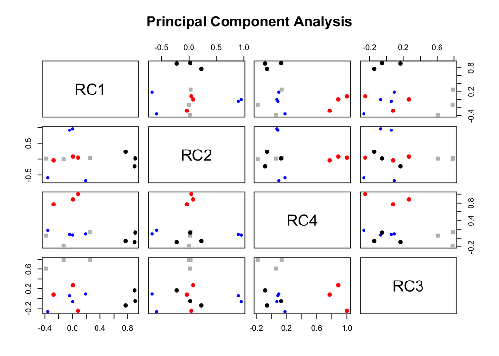

```r
plot(pca_final)
```

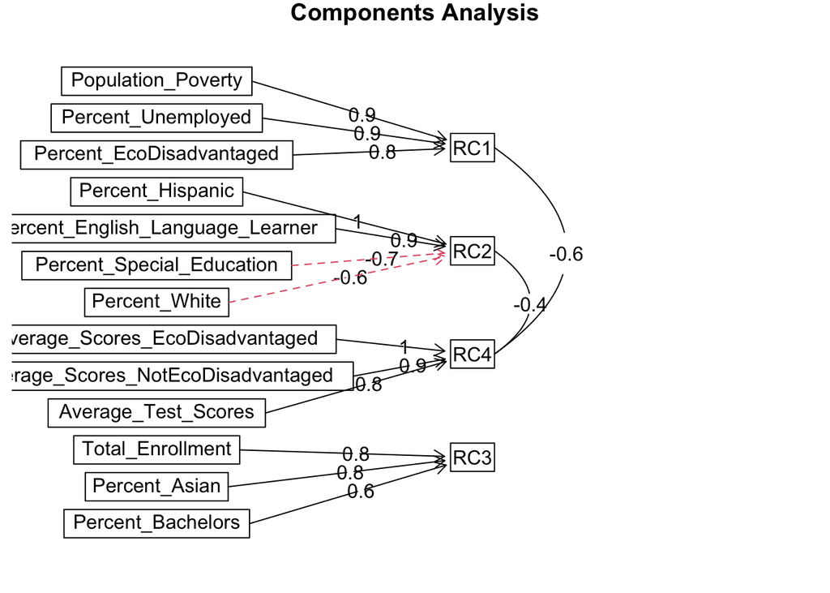

```r
#component 1 is black
#component 2 is blue
#component 3 is red
#component 4 is grey

fa.diagram(pca_final)
```

*Here we see four components. The components can be named as following:*

**Component 1**: Disadvantaged_students

**Component 2**: Specialized_demographics

**Component 3**: Urban_students

**Component 4**: Test_scores

## 4.5 CSV

```r
#we need the pca scores
pca_final_scores <- as.data.frame(pca_final$scores) #scores for each factor

#rename using the component names we chose
pca_final_scores <- pca_final_scores %>%
  rename(Disadvantaged_students = RC1, Specialized_demographics = RC2, Urban_students = RC3, Test_scores = RC4)

#combine df

str(data)
```

```
## spc_tbl_ [933 × 19] (S3: spec_tbl_df/tbl_df/tbl/data.frame)
##  $ sedametro     : num [1:933] 10100 10140 10180 10220 10300 ...
##  $ sedametroname : chr [1:933] "Aberdeen, SD" "Aberdeen, WA" "Abilene, TX" "Ada, OK" ...
##  $ avg_test_all  : num [1:933] 0.21221 -0.23448 0.00239 -0.08299 -0.04656 ...
##  $ avg_test_ecd  : num [1:933] -0.049 -0.41 -0.259 -0.265 -0.266 ...
##  $ avg_test_nec  : num [1:933] 0.3517 0.0985 0.3419 0.1902 0.1167 ...
##  $ metro_or_micro: chr [1:933] "Micro" "Micro" "Metro" "Micro" ...
##  $ perurban      : num [1:933] 0 0 65.6 0 0 ...
##  $ perell        : num [1:933] 2.104 5.409 2.745 1.848 0.286 ...
##  $ perspeced     : num [1:933] 14.3 15 11 16 13.3 ...
##  $ pernam        : num [1:933] 5.125 6.783 0.415 37.138 0.42 ...
##  $ perasn        : num [1:933] 1.588 1.448 1.528 0.659 0.54 ...
##  $ perhsp        : num [1:933] 2.72 18.64 33.68 6.58 9.01 ...
##  $ perblk        : num [1:933] 1.62 1.12 8.67 2.56 1.71 ...
##  $ perwht        : num [1:933] 88.9 72 55.7 53.1 88.3 ...
##  $ perecd        : num [1:933] 41.3 62.6 56.7 59.9 42.2 ...
##  $ totenrl       : num [1:933] 2720 4706 12618 3020 5653 ...
##  $ perbaplus     : num [1:933] 26.2 15 21.6 26.5 19.9 ...
##  $ perunemp      : num [1:933] 2.43 9.69 4.67 5.47 7.4 ...
##  $ perpoverty    : num [1:933] 11.3 15.9 15.7 17.8 12.2 ...
##  - attr(*, "spec")=
##   .. cols(
##   ..   sedametro = col_double(),
##   ..   sedametroname = col_character(),
##   ..   avg_test_all = col_double(),
##   ..   avg_test_ecd = col_double(),
##   ..   avg_test_nec = col_double(),
##   ..   metro_or_micro = col_character(),
##   ..   perurban = col_double(),
##   ..   perell = col_double(),
##   ..   perspeced = col_double(),
##   ..   pernam = col_double(),
##   ..   perasn = col_double(),
##   ..   perhsp = col_double(),
##   ..   perblk = col_double(),
##   ..   perwht = col_double(),
##   ..   perecd = col_double(),
##   ..   totenrl = col_double(),
##   ..   perbaplus = col_double(),
##   ..   perunemp = col_double(),
##   ..   perpoverty = col_double()
##   .. )
##  - attr(*, "problems")=<externalptr>
```

```r
final_data <- cbind(data, pca_final_scores)
str(final_data)
```

```
## 'data.frame':    933 obs. of  23 variables:
##  $ sedametro               : num  10100 10140 10180 10220 10300 ...
##  $ sedametroname           : chr  "Aberdeen, SD" "Aberdeen, WA" "Abilene, TX" "Ada, OK" ...
##  $ avg_test_all            : num  0.21221 -0.23448 0.00239 -0.08299 -0.04656 ...
##  $ avg_test_ecd            : num  -0.049 -0.41 -0.259 -0.265 -0.266 ...
##  $ avg_test_nec            : num  0.3517 0.0985 0.3419 0.1902 0.1167 ...
##  $ metro_or_micro          : chr  "Micro" "Micro" "Metro" "Micro" ...
##  $ perurban                : num  0 0 65.6 0 0 ...
##  $ perell                  : num  2.104 5.409 2.745 1.848 0.286 ...
##  $ perspeced               : num  14.3 15 11 16 13.3 ...
##  $ pernam                  : num  5.125 6.783 0.415 37.138 0.42 ...
##  $ perasn                  : num  1.588 1.448 1.528 0.659 0.54 ...
##  $ perhsp                  : num  2.72 18.64 33.68 6.58 9.01 ...
##  $ perblk                  : num  1.62 1.12 8.67 2.56 1.71 ...
##  $ perwht                  : num  88.9 72 55.7 53.1 88.3 ...
##  $ perecd                  : num  41.3 62.6 56.7 59.9 42.2 ...
##  $ totenrl                 : num  2720 4706 12618 3020 5653 ...
##  $ perbaplus               : num  26.2 15 21.6 26.5 19.9 ...
##  $ perunemp                : num  2.43 9.69 4.67 5.47 7.4 ...
##  $ perpoverty              : num  11.3 15.9 15.7 17.8 12.2 ...
##  $ Disadvantaged_students  : num  -1.5394 0.812 -0.3283 0.0943 -0.4693 ...
##  $ Specialized_demographics: num  -0.568 -0.238 0.585 -0.337 -0.707 ...
##  $ Test_scores             : num  1.128 -0.965 0.202 -0.166 -0.293 ...
##  $ Urban_students          : num  -0.414 -0.485 -0.304 -0.244 -0.605 ...
```

```r
write.csv(final_data,"metromicro_pca.csv", row.names=FALSE)
```

# 5 Machine Learning

```r
model <- read_csv("metromicro_pca.csv", show_col_types = FALSE) #Bring in the final CSV file
str(model) #Check the structure to make sure our variables are correctly identified as "character" or "numeric"
```

```
## spc_tbl_ [933 × 23] (S3: spec_tbl_df/tbl_df/tbl/data.frame)
##  $ sedametro               : num [1:933] 10100 10140 10180 10220 10300 ...
##  $ sedametroname           : chr [1:933] "Aberdeen, SD" "Aberdeen, WA" "Abilene, TX" "Ada, OK" ...
##  $ avg_test_all            : num [1:933] 0.21221 -0.23448 0.00239 -0.08299 -0.04656 ...
##  $ avg_test_ecd            : num [1:933] -0.049 -0.41 -0.259 -0.265 -0.266 ...
##  $ avg_test_nec            : num [1:933] 0.3517 0.0985 0.3419 0.1902 0.1167 ...
##  $ metro_or_micro          : chr [1:933] "Micro" "Micro" "Metro" "Micro" ...
##  $ perurban                : num [1:933] 0 0 65.6 0 0 ...
##  $ perell                  : num [1:933] 2.104 5.409 2.745 1.848 0.286 ...
##  $ perspeced               : num [1:933] 14.3 15 11 16 13.3 ...
##  $ pernam                  : num [1:933] 5.125 6.783 0.415 37.138 0.42 ...
##  $ perasn                  : num [1:933] 1.588 1.448 1.528 0.659 0.54 ...
##  $ perhsp                  : num [1:933] 2.72 18.64 33.68 6.58 9.01 ...
##  $ perblk                  : num [1:933] 1.62 1.12 8.67 2.56 1.71 ...
##  $ perwht                  : num [1:933] 88.9 72 55.7 53.1 88.3 ...
##  $ perecd                  : num [1:933] 41.3 62.6 56.7 59.9 42.2 ...
##  $ totenrl                 : num [1:933] 2720 4706 12618 3020 5653 ...
##  $ perbaplus               : num [1:933] 26.2 15 21.6 26.5 19.9 ...
##  $ perunemp                : num [1:933] 2.43 9.69 4.67 5.47 7.4 ...
##  $ perpoverty              : num [1:933] 11.3 15.9 15.7 17.8 12.2 ...
##  $ Disadvantaged_students  : num [1:933] -1.5394 0.812 -0.3283 0.0943 -0.4693 ...
##  $ Specialized_demographics: num [1:933] -0.568 -0.238 0.585 -0.337 -0.707 ...
##  $ Test_scores             : num [1:933] 1.128 -0.965 0.202 -0.166 -0.293 ...
##  $ Urban_students          : num [1:933] -0.414 -0.485 -0.304 -0.244 -0.605 ...
##  - attr(*, "spec")=
##   .. cols(
##   ..   sedametro = col_double(),
##   ..   sedametroname = col_character(),
##   ..   avg_test_all = col_double(),
##   ..   avg_test_ecd = col_double(),
##   ..   avg_test_nec = col_double(),
##   ..   metro_or_micro = col_character(),
##   ..   perurban = col_double(),
##   ..   perell = col_double(),
##   ..   perspeced = col_double(),
##   ..   pernam = col_double(),
##   ..   perasn = col_double(),
##   ..   perhsp = col_double(),
##   ..   perblk = col_double(),
##   ..   perwht = col_double(),
##   ..   perecd = col_double(),
##   ..   totenrl = col_double(),
##   ..   perbaplus = col_double(),
##   ..   perunemp = col_double(),
##   ..   perpoverty = col_double(),
##   ..   Disadvantaged_students = col_double(),
##   ..   Specialized_demographics = col_double(),
##   ..   Test_scores = col_double(),
##   ..   Urban_students = col_double()
##   .. )
##  - attr(*, "problems")=<externalptr>
```

```r
#we only want our outcome and predictor variables

model_lr <- model[,c(6, 20:23)] #I only want to analyze my variables of interest

#rename the variables using the dplyr package
model_lr <- model_lr %>% rename(Metro_or_Micro = metro_or_micro)

str(model_lr)
```

```
## tibble [933 × 5] (S3: tbl_df/tbl/data.frame)
##  $ Metro_or_Micro          : chr [1:933] "Micro" "Micro" "Metro" "Micro" ...
##  $ Disadvantaged_students  : num [1:933] -1.5394 0.812 -0.3283 0.0943 -0.4693 ...
##  $ Specialized_demographics: num [1:933] -0.568 -0.238 0.585 -0.337 -0.707 ...
##  $ Test_scores             : num [1:933] 1.128 -0.965 0.202 -0.166 -0.293 ...
##  $ Urban_students          : num [1:933] -0.414 -0.485 -0.304 -0.244 -0.605 ...
```

## 5.1 Data Descriptives

*Make sure outcome variable is binary*

Outcome variable of interest is type of district (metropolitan or micropolitan). The outcome variable is binary. Students will either come from a metropolitan or micropolitan district.

*Check to make sure classes are roughly balanced*

```r
library(plyr) #download the package plyr to check frequency count of each class
count(model_lr$Metro_or_Micro) #check count of each class
```

```
##       x freq
## 1 Metro  400
## 2 Micro  533
```

```r
#there are 400 metro school districts and 533 micro school districts in the data set
```

Industry standard states that to be balanced, minority classes (the smaller of the class) should be at least 40% of the proportion of the data set. Here, n=400 (minority class) is over 40% of the data set (n=933). Through the following visualization and industry standard, we can claim that the classes are balanced (Google Developers, 2022).

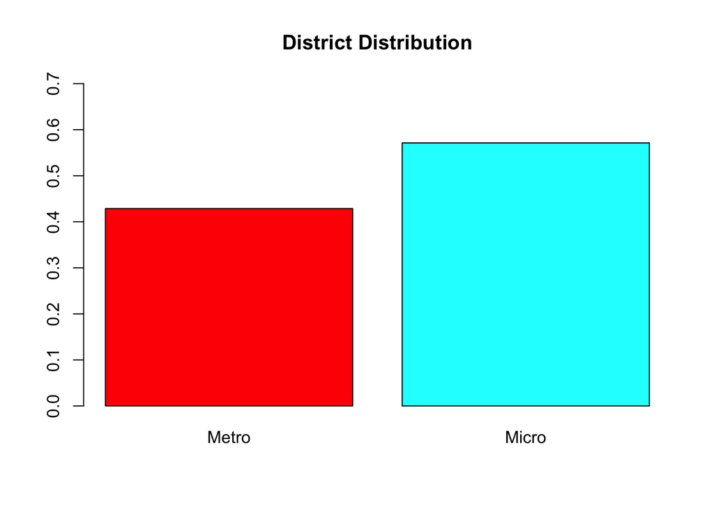

```r
barplot(prop.table(table(model_lr$Metro_or_Micro)),
        col = rainbow(2),
        ylim = c(0, 0.7),
        main = "District Distribution") #visualization of classes
```

*Scale numeric predictor variables*

```r
model_scaled <- model_lr %>%
  mutate_at(c(2:5), ~(scale(.) %>% as.vector))
  #scale all variables except the outcome variable so mean is zero and values are standardized to SD from zero

str(model_scaled)
```

```
## tibble [933 × 5] (S3: tbl_df/tbl/data.frame)
##  $ Metro_or_Micro          : chr [1:933] "Micro" "Micro" "Metro" "Micro" ...
##  $ Disadvantaged_students  : num [1:933] -1.5394 0.812 -0.3283 0.0943 -0.4693 ...
##  $ Specialized_demographics: num [1:933] -0.568 -0.238 0.585 -0.337 -0.707 ...
##  $ Test_scores             : num [1:933] 1.128 -0.965 0.202 -0.166 -0.293 ...
##  $ Urban_students          : num [1:933] -0.414 -0.485 -0.304 -0.244 -0.605 ...
```

```r
psych::describe(model_scaled) #from this summary description, I see that all numeric variables have a mean of 0 and an SD of 1
```

```
##                          vars   n mean  sd median trimmed  mad   min  max range
## Metro_or_Micro*             1 933 1.57 0.5   2.00    1.59 0.00  1.00 2.00  1.00
## Disadvantaged_students      2 933 0.00 1.0  -0.08   -0.05 0.89 -3.01 4.05  7.07
## Specialized_demographics    3 933 0.00 1.0  -0.24   -0.15 0.69 -1.64 5.25  6.89
## Test_scores                 4 933 0.00 1.0   0.09    0.04 0.97 -4.19 3.52  7.71
## Urban_students              5 933 0.00 1.0  -0.29   -0.17 0.56 -1.17 7.96  9.12
##                           skew kurtosis   se
## Metro_or_Micro*          -0.29    -1.92 0.02
## Disadvantaged_students    0.65     1.02 0.03
## Specialized_demographics  1.57     3.00 0.03
## Test_scores              -0.48     0.78 0.03
## Urban_students            3.09    14.73 0.03
```

**Make sure outcome variable is a factor**

```r
#the outcome variable label is currently numeric and it needs to be a factor

model_scaled$Metro_or_Micro <- as.factor(model_scaled$Metro_or_Micro) #Metro is "1" and Micro is "2"

str(model_scaled) #check structure to make sure that "label" variable is now a factor, which checks out!
```

```
## tibble [933 × 5] (S3: tbl_df/tbl/data.frame)
##  $ Metro_or_Micro          : Factor w/ 2 levels "Metro","Micro": 2 2 1 2 2 1 2 1 1 1 ...
##  $ Disadvantaged_students  : num [1:933] -1.5394 0.812 -0.3283 0.0943 -0.4693 ...
##  $ Specialized_demographics: num [1:933] -0.568 -0.238 0.585 -0.337 -0.707 ...
##  $ Test_scores             : num [1:933] 1.128 -0.965 0.202 -0.166 -0.293 ...
##  $ Urban_students          : num [1:933] -0.414 -0.485 -0.304 -0.244 -0.605 ...
```

```r
table(model_scaled$Metro_or_Micro) #as number of people in micro are more, we predict model will predict more students in micro districts
```

```
##
## Metro Micro
##   400   533
```

*The outcome variable is the type of district and the predictor variables are the four components gathered from the PCA above.*

## 5.2 Check for Suppression Effects

```r
model_scaled %>%
  group_by(Metro_or_Micro) %>%
  summarise_at(1:4, funs(mean, sd)) #when using the group-by function, R assumes that the tibble has only has 4 variables #get the mean and SD of each of the predictor variables based on the outcome variable binary
```

```
## # A tibble: 2 × 9
##   Metro_or_Micro Disad…¹ Speci…² Test_…³ Urban…⁴ Disad…⁵ Speci…⁶ Test_…⁷ Urban…⁸
##   <fct>            <dbl>   <dbl>   <dbl>   <dbl>   <dbl>   <dbl>   <dbl>   <dbl>
## 1 Metro           -0.177   0.160  0.0453   0.600   0.855   0.980   0.906   1.22
## 2 Micro            0.133  -0.120 -0.0340  -0.450   1.08    0.999   1.06    0.410
## # … with abbreviated variable names ¹Disadvantaged_students_mean,
## #   ²Specialized_demographics_mean, ³Test_scores_mean, ⁴Urban_students_mean,
## #   ⁵Disadvantaged_students_sd, ⁶Specialized_demographics_sd, ⁷Test_scores_sd,
## #   ⁸Urban_students_sd
```

## 5.3 Check for Multicollinearity

*Check for multicollinearity*

```r
#check for multicollinearity

model_corr <- model_scaled[, c(2:5)] #create a tibble of the predictor variables

cor(model_corr) #check correlation
```

```
##                          Disadvantaged_students Specialized_demographics
## Disadvantaged_students                1.0000000                0.2820986
## Specialized_demographics              0.2820986                1.0000000
## Test_scores                          -0.5691501               -0.3666936
## Urban_students                       -0.2328391                0.1937153
##                          Test_scores Urban_students
## Disadvantaged_students    -0.5691501     -0.2328391
## Specialized_demographics  -0.3666936      0.1937153
## Test_scores                1.0000000      0.1193627
## Urban_students             0.1193627      1.0000000
```

```r
#no threats of multicollinearity
```

The data tables above further shows that there is no suppression effect nor multicollinearity so we can move ahead to creating a predictive model for the data set. We can see that when the correlations are ordered by strength, the strongest correlation is .57 so there is no evidence of multicollinearity (>.80) in the data.

## 5.4 Regression model

**10 fold cross-validation**

Next, we are going to use a statistical resampling procedure method called 10-fold cross validation to test the strength of our model (Brownlee, 2018). We will use the PCA data we have from our given data set to analyze how well this model can make predictions outside of this data set.

```r
library(caret) #call in the caret package #Classification And REgression Training #simplifies the creation of predictive models
library(MASS) #call in the mass package #Modern Applied Statistics with S
#set seed
set.seed(123)

# Set up repeated k-fold cross-validation
train.control <- trainControl(method = "cv", number = 10)
#method CV means cross validation, number is 10 because we are doing 10 fold cross-validation


#the LM model used
lr_cv10 <- train(Metro_or_Micro ~., #~. indicates to pull all variables after Metro_or_Micro
                 data = model_scaled, #our dataset
                 method="glmStepAIC", # Step wise AIC (estimator of prediction error) from maas package
                 direction="backward",
                 trControl = train.control,
                 family = "binomial")
```

[output not shown]

[output cut: 226 more lines]

```
## .outcome ~ Specialized_demographics + Test_scores + Urban_students
##
##                            Df Deviance     AIC
## - Specialized_demographics  1   845.48  851.48
## <none>                          844.49  852.49
## - Test_scores               1   847.89  853.89
## - Urban_students            1  1247.55 1253.55
##
## Step:  AIC=851.48
## .outcome ~ Test_scores + Urban_students
##
##                  Df Deviance     AIC
## <none>                845.48  851.48
## - Test_scores     1   851.14  855.14
## - Urban_students  1  1272.95 1276.95
```

```r
summary(lr_cv10) #find residuals and average #Urban_students and Test_scores are significant
```

```
##
## Call:
## NULL
##
## Deviance Residuals:
##     Min       1Q   Median       3Q      Max
## -2.2093  -0.6789   0.4349   0.6850   3.5094
##
## Coefficients:
##                Estimate Std. Error z value Pr(>|z|)
## (Intercept)    -0.06175    0.09400  -0.657   0.5113
## Test_scores     0.20402    0.08568   2.381   0.0173 *
## Urban_students -2.89357    0.20590 -14.053   <2e-16 ***
## ---
## Signif. codes:  0 '***' 0.001 '**' 0.01 '*' 0.05 '.' 0.1 ' ' 1
##
## (Dispersion parameter for binomial family taken to be 1)
##
##     Null deviance: 1274.39  on 932  degrees of freedom
## Residual deviance:  845.48  on 930  degrees of freedom
## AIC: 851.48
##
## Number of Fisher Scoring iterations: 6
```

```r
str(lr_cv10)
```

[output not shown]

[output cut: 218 more lines]

[output not shown]

**Get predicted and actual values**

```r
predicted <- unname(lr_cv10$finalModel$fitted.values) #change named vector to unname

model_scaled$predicted.probabilities<-predicted #get predicted values

model_scaled <- model_scaled %>%
  #assign 1 to Metropolitan Districts, 2 to Micropolitan Districts
  mutate(actual = ifelse(Metro_or_Micro == "Metro", 1, 2)) %>%
  #assign 1 to .50 and less and 2 to anything else
  mutate(predicted = ifelse(predicted.probabilities < .50, 1, 2))

#create factors for predicted and actual
model_scaled$predicted <- as.factor(model_scaled$predicted)
model_scaled$actual <- as.factor(model_scaled$actual)

str(model_scaled)
```

```
## tibble [933 × 8] (S3: tbl_df/tbl/data.frame)
##  $ Metro_or_Micro          : Factor w/ 2 levels "Metro","Micro": 2 2 1 2 2 1 2 1 1 1 ...
##  $ Disadvantaged_students  : num [1:933] -1.5394 0.812 -0.3283 0.0943 -0.4693 ...
##  $ Specialized_demographics: num [1:933] -0.568 -0.238 0.585 -0.337 -0.707 ...
##  $ Test_scores             : num [1:933] 1.128 -0.965 0.202 -0.166 -0.293 ...
##  $ Urban_students          : num [1:933] -0.414 -0.485 -0.304 -0.244 -0.605 ...
##  $ predicted.probabilities : num [1:933] 0.797 0.759 0.702 0.648 0.836 ...
##  $ actual                  : Factor w/ 2 levels "1","2": 2 2 1 2 2 1 2 1 1 1 ...
##  $ predicted               : Factor w/ 2 levels "1","2": 2 2 2 2 2 1 2 1 2 1 ...
```

```r
table(model_scaled$actual) #let's see our final values
```

```
##
##   1   2
## 400 533
```

```r
# create confusion matrix using the confusionMatrix function
confusionMatrix(model_scaled$actual, model_scaled$predicted,
                mode = "everything",
                positive="1") #positive values represent Metro districts
```

```
## Confusion Matrix and Statistics
##
##           Reference
## Prediction   1   2
##          1 265 135
##          2  64 469
##
##                Accuracy : 0.7867
##                  95% CI : (0.759, 0.8126)
##     No Information Rate : 0.6474
##     P-Value [Acc > NIR] : < 2.2e-16
##
##                   Kappa : 0.5547
##
##  Mcnemar's Test P-Value : 6.971e-07
##
##             Sensitivity : 0.8055
##             Specificity : 0.7765
##          Pos Pred Value : 0.6625
##          Neg Pred Value : 0.8799
##               Precision : 0.6625
##                  Recall : 0.8055
##                      F1 : 0.7270
##              Prevalence : 0.3526
##          Detection Rate : 0.2840
##    Detection Prevalence : 0.4287
##       Balanced Accuracy : 0.7910
##
##        'Positive' Class : 1
##
```

## 5.5 Mosaic Plot

```r
#first make a table
mosaic_table <- table(model_scaled$actual, model_scaled$predicted)
mosaic_table #make sure everything looks good with the table
```

```
##
##       1   2
##   1 265 135
##   2  64 469
```

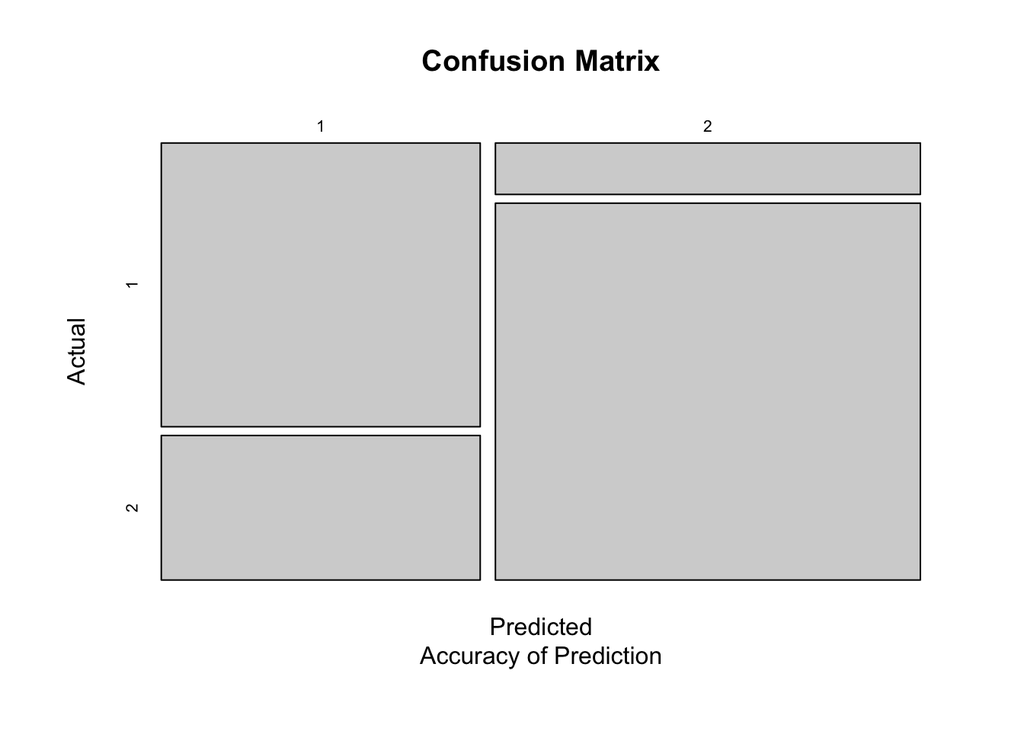

```r
#next plot a simple mosaic
mosaicplot(mosaic_table,
           main = "Confusion Matrix",
           sub = "Accuracy of Prediction",
           xlab = "Predicted",
           ylab = "Actual",
           color = "lightgray",
           border = "black")
```

# 6 Discussion

This study aimed to answer the following research question: Can components derived from the SEDA data set using a PCA predict whether 3rd to 8th graders live in micropolitan or metropolitan dis- tricts in the United States?

# 7 References

[1] Analysis Inn. (2020, May 9). KMO and Bartlett’s Test of Sphericity. Analysis Inn. https://www.analysisinn.com/post/kmo-and-bartlett-s-test-of-sphericity/

[2] Baker, B. D., Srikanth, A., Green III, P. C., & Cotto, R. (2020). School funding disparities and the plight of Latinx children. Education Policy Analysis Archives, 28, 135–. https://doi.org/10.14507/epaa.28.5282

[3] Baloglu, O., Latifi, S. Q., & Nazha, A. (2022). What is machine learning? Archives of Disease in Childhood. Ed-ucation and Practice Edition, 107(5), 386–388. https://doi.org/10.1136/archdischild-2020-319415

[4] Brownlee, J. (2018, May 23). A Gentle Introduction to k-fold Cross-Validation. Machine Learning Mastery. Re-trieved April 7, 2023, from https://machinelearningmastery.com/k-fold-cross-validation/

[5] Dhaliwal, T. K., & Bruno, P. (2021). The Rural/Nonrural Divide? K–12 District Spending and Implications of Eq-uity-Based School Funding. AERA Open, 7. https://doi.org/10.1177/2332858420982549

[6] UCLA: Statistical Consulting Group. (n.d.). Factor Varia-bles. Retrieved May 1, 2023, from https://stats.oarc.ucla.edu/r/modules/factor-variables/

[7] Fahle, E. M., Chavez, B., Kalogrides, D., Shear, B. R., Rear-don, S. F., & Ho, A. D. (2021). Stanford Education Data Archive: Technical Documentation (Version 4.1). Re-trieved from http://purl.stanford.edu/db586ns4974.

[8] Federal Reserve System (2023, April 5). Micro Data Ref-erence Manual. Data Dictionary Item Number 9153: Core Based Statistical Area Type. Retrieved April 7, 2023, from https://www.federalreserve.gov/apps/mdrm/data-dictionary

[9] Frisch, R. (1934). Statistical confluence analysis by means of complete regression systems (No. 5). Universite-tets Økonomiske Institutt.

[10] Galla, B. M., Wood, J. J., Tsukayama, E., Har, K., Chiu, A. W., & Langer, D. A. (2014). A longitudinal multilevel model analysis of the within-person and between-person effect of effortful engagement and academic self-efficacy on academic performance. Journal of School Psychology, 52(3), 295–308. https://doi.org/10.1016/j.jsp.2014.04.001

[11] Google Developers (2022, July 18). Imbalanced Data. Machine Learning. Retrieved April 5, 2023, from https://developers.google.com/machine-learning/data-prep/construct/sampling-splitting/imbalanced-data

[12] Holt, M. K., Finkelhor, D., & Kantor, G. K. (2007). Multi-ple victimization experiences of urban elementary school students: Associations with psychosocial functioning and academic performance. Child Abuse & Neglect, 31(5), 503–515. https://doi.org/10.1016/j.chiabu.2006.12.006

[13] Irgens, G. A., Adisa, I., Bailey, C., & Quesada, H. V. (2022). Designing with and for Youth: A Participatory Design Research Approach for Critical Machine Learning Education. Educational Technology & Society, 25(4), 126+. https://link-gale-com.proxy.library.vanderbilt.edu/apps/doc/A730948443/AONE?u=tel_a_vanderbilt&sid=bookmark-AONE&xid=746d6862

[14] Jolliffe, I. T., & Cadima, J. (2016). Principal component analysis: a review and recent developments. Philosophi-cal Transactions of the Royal Society of London. Series A: Mathematical, Physical, and Engineering Sciences, 374(2065), 20150202–20150202. https://doi.org/10.1098/rsta.2015.0202

[15] Mitchell, T. (1997). Machine Learning. McGraw Hill.

[16] Narkhede, S. (2018, May 9). Understanding Confusion Matrix. Towards Data Science. Retrieved May 1, 2023, from https://towardsdatascience.com/understanding-confusion-matrix-a9ad42dcfd62

[17] Ng, J. C., & Baker, B. D. (2006, Spring). Big changes in small town America: A macro level analysis of micropoli-tan schooling. Paper presented at the Annual Meeting of the American Educational Research Association, San Francisco, CA.

[18] OECD/European Commission (2020), Cities in the World: A New Perspective on Urbanisation, OECD Ur-ban Studies, OECD Publishing, Paris, https://doi.org/10.1787/d0efcbda-en.

[19] R Team (2014). R: A language and environment for statis-tical computing. R Foundation for Statistical Computing, Vienna, Austria. 2013: ISBN 3-900051-07-0.

[20] Reardon, S. F., Fahle, E. M., Ho, A. D., Shear, B. R., Ka-logrides, & Saliba, J. (2022). Stanford Education Data Ar-chive (Version SEDA2022). Retrieved from http://purl.stanford.edu/db586ns4974.

[21] Schaie, K. W. (Klaus W., & Roberts, J. (1971). School achievement of children by demographic and socioeco-nomic factors, United States [by K. Warner Schaie and Jean Roberts]. National Center for Health Statistics; [for sale by the Supt. of Docs., U.S. Govt. Print. Off., Washing-ton].

[22] The United States Census Bureau (2021). Classification of Metropolitan Areas. Metropolitan Areas. Retrieved May 1, 2023, from https://www2.census.gov/geo/pdfs/reference/GARM/Ch13GARM.pdf